# Etape 5 : Visualisations avec données DataFrame_Complet.csv

## 2. Histogramme des Base Severity

```
(array([  0., 100., 200., 300., 400., 500., 600.]),
 [Text(0, 0.0, '0'),
```

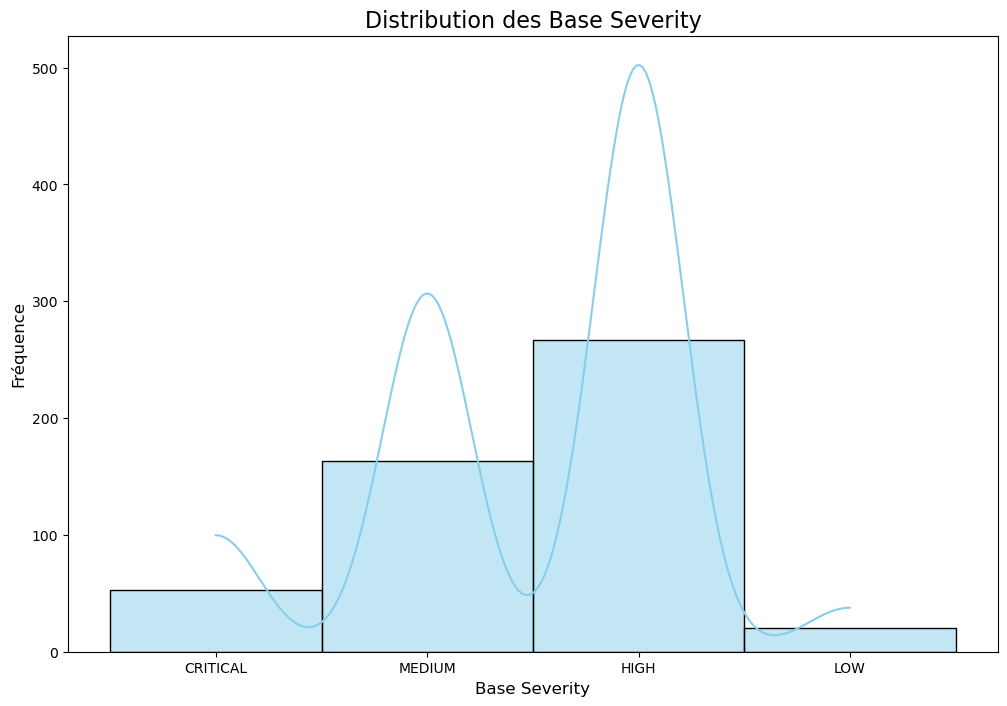

```python
plt.figure(figsize=(12, 8))
sns.histplot(df_cve_unique_full['Base_severity'], bins=10, kde=True, color='skyBlue')
plt.title('Distribution des Base Severity', fontsize=16)
plt.xlabel('Base Severity', fontsize=12)
plt.ylabel('Fréquence', fontsize=12)
plt.xticks(fontsize=10)
plt.yticks(fontsize=10)
```

## Interpréation - Distribution des Base Severity

Ce graphique complète le précédent sur la distribution des scores CVSS.

Le pic principal des scores CVSS était dans la catégorie "HIGH" (7.0-8.9 = High). Le deuxième pic des scores CVSS vorrespond à la catégorie "MEDIUM" (4.0-6.9 = Medium). Les scores très élevés (9.0-10.0 = Critical) étaient moins fréquents, ce qui est cohérent avec le faible nombre de vulnérabilités "CRITICAL" sur ce graphique. Les scores très bas (0.1-3.9 = Low) étaient également très rares, correspondant au quasi-zéro de la catégorie "LOW".

La catégorie la plus fréquente est "HIGH", ce qui correspond bien au pic des scores CVSS autour de 8. La catégorie "MEDIUM" est également bien représentée. Les vulnérabilités "CRITICAL" sont rares, et celles de "LOW" sont presque inexistantes.

En conclusion, ce graphique indique que la majeure partie des vulnérabilités analysées sont de sévérité "HIGH", suivies par "MEDIUM", avec un nombre très limité de vulnérabilités "CRITICAL" ou "LOW".

## 3. Diagramme circulaire des types de vulnérabilités (CWE)

### Identifier les catégories de faiblesses les plus fréquentes (par exemple : Injection SQL, Débordement de mémoire, Authentification contournée).

```
(-1.0999981719269822,
 1.099999524938944,
 -1.099999999809114,
 1.0999999960193572)
```

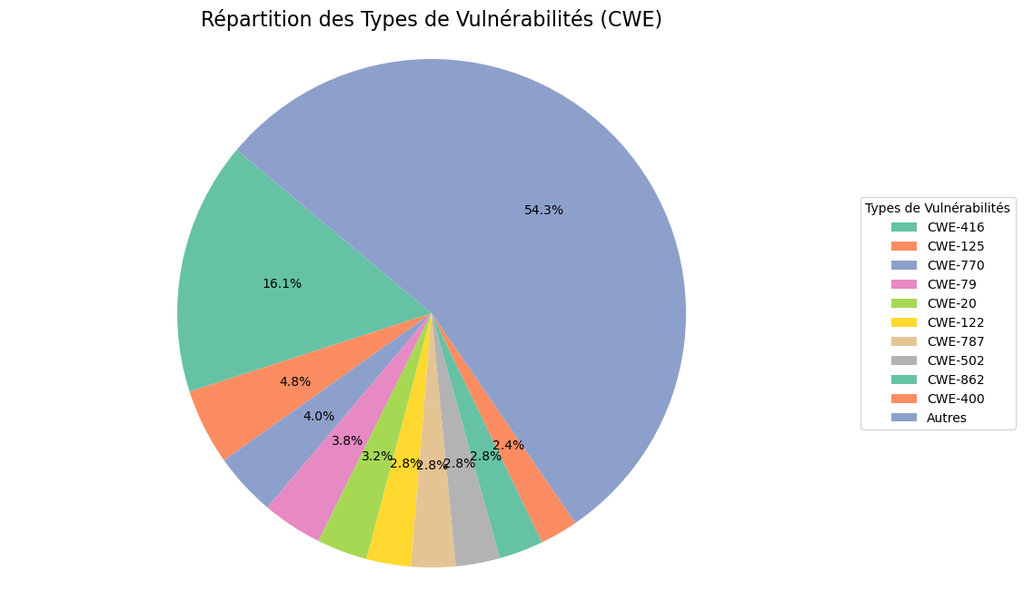

```python
plt.figure(figsize=(12, 8))
cwe_counts = df_cve_unique['CWE'].value_counts()

top_n_cwe = 10
if len(cwe_counts) > top_n_cwe:
    other_cwe_count = cwe_counts.iloc[top_n_cwe:].sum()
    cwe_counts = cwe_counts.iloc[:top_n_cwe]
    cwe_counts['Autres'] = other_cwe_count

wedges, texts, autotexts = plt.pie(
    cwe_counts,
    autopct='%1.1f%%',
    startangle=140,
    colors=sns.color_palette("Set2")
)

plt.legend(wedges, cwe_counts.index, title="Types de Vulnérabilités", loc="center left", bbox_to_anchor=(1, 0, 0.5, 1))

plt.title('Répartition des Types de Vulnérabilités (CWE)', fontsize=16)
plt.axis('equal')
```

## Interprétation - Répartition des Types de Vulnérabilités (CWE)

Ce graphique circulaire montre la répartition des types de vulnérabilités (CWE). La catégorie "Autres" (Autres CWE non spécifiées ou moins fréquentes) représente la majorité des vulnérabilités, avec 54,3%. Parmi les types de CWE explicitement nommés, CWE-416 (Use After Free) est le plus courant avec 16,1%, suivi de CWE-125 (Out-of-bounds Read) à 4,8% et CWE-770 (Allocation of Resources Without Limits or Throttling) à 4,0%. Les autres vulnérabilités nommées représentent chacune moins de 4% des vulnérabilités.

# 4. Courbe des scores EPSS

### Comprendre la probabilité d'exploitation des vulnérabilités recensées et les prioriser en fonction de leur risque réel

```
(array([0., 1., 2., 3., 4., 5., 6., 7., 8., 9.]),
 [Text(0, 0.0, '0'),
```

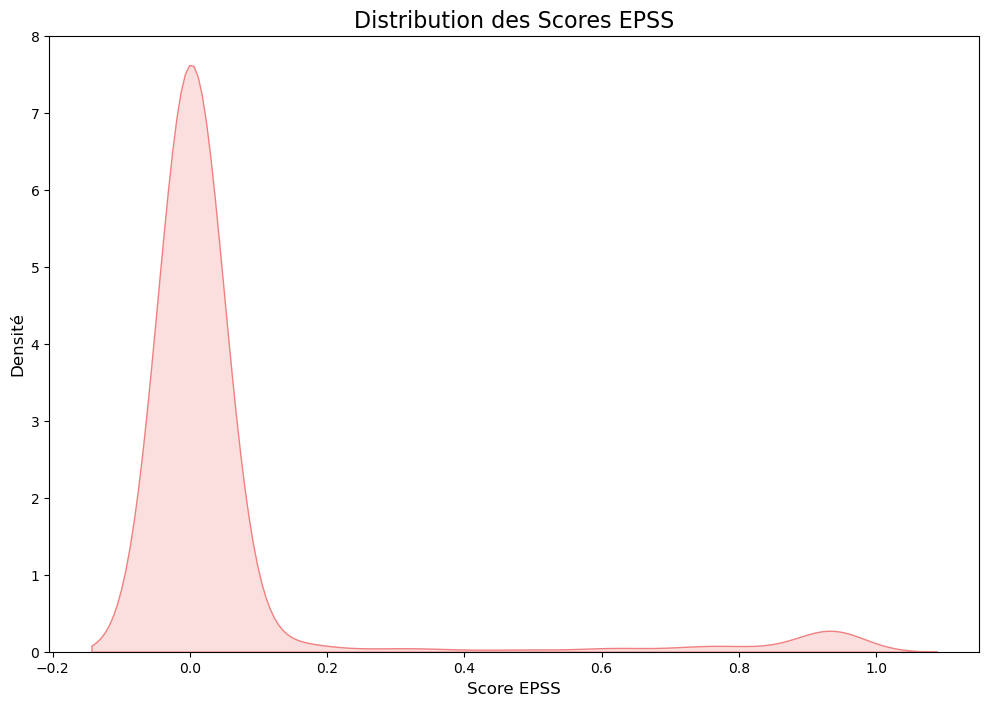

```python
plt.figure(figsize=(12, 8))
sns.kdeplot(df_cve_unique['EPSS_score'], fill=True, color='lightcoral')
plt.title('Distribution des Scores EPSS', fontsize=16)
plt.xlabel('Score EPSS', fontsize=12)
plt.ylabel('Densité', fontsize=12)
plt.xticks(fontsize=10)
plt.yticks(fontsize=10)
```

## Interprétation - Courbe des scores EPSS

Ce graphique montre la distribution des Scores EPSS (Exploit Prediction Scoring System). La quasi-totalité des vulnérabilités ont des scores EPSS très bas, concentrés autour de 0. Cela signifie que, pour la plupart des vulnérabilités, la probabilité qu'elles soient exploitées en réalité est très faible. Il y a un tout petit pic secondaire vers 0.9, indiquant qu'une très petite proportion de vulnérabilités a une forte probabilité d'être exploitée.

# 5. Classement des produits ou éditeurs les plus affectés

### Mettre en lumière les systèmes les plus vulnérables et cibler les actions à entreprendre

```
([0, 1, 2, 3, 4, 5, 6],
 [Text(0, 0, 'Linux'),
```

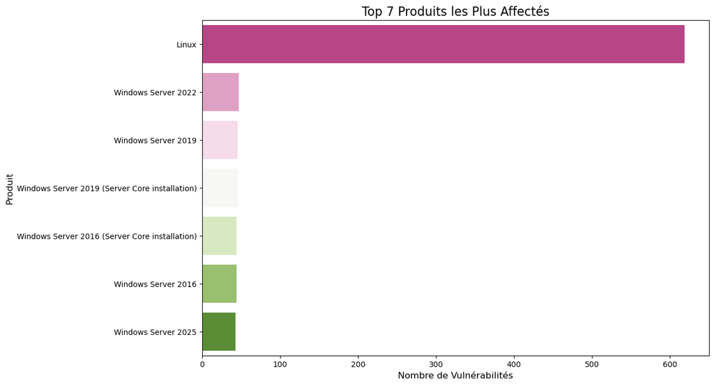

```python
plt.figure(figsize=(12, 8))
top_affected_products = df_produit_unique['product'].value_counts().head(7)
sns.barplot(x=top_affected_products.values, y=top_affected_products.index, palette='PiYG', hue=top_affected_products.index, legend=False)
plt.title('Top 7 Produits les Plus Affectés', fontsize=16)
plt.xlabel('Nombre de Vulnérabilités', fontsize=12)
plt.ylabel('Produit', fontsize=12)
plt.xticks(fontsize=10)
plt.yticks(fontsize=10)
```